# Amazon Fine Food Reviews Analysis

Data Source: https://www.kaggle.com/snap/amazon-fine-food-reviews

EDA: https://nycdatascience.com/blog/student-works/amazon-fine-foods-visualization/

The Amazon Fine Food Reviews dataset consists of reviews of fine foods from Amazon.

Number of reviews: 568,454  
Number of users: 256,059  
Number of products: 74,258  
Timespan: Oct 1999 - Oct 2012  
Number of Attributes/Columns in data: 10

Attribute Information:

1. Id
2. ProductId - unique identifier for the product
3. UserId - unqiue identifier for the user
4. ProfileName
5. HelpfulnessNumerator - number of users who found the review helpful
6. HelpfulnessDenominator - number of users who indicated whether they found the review helpful or not
7. Score - rating between 1 and 5
8. Time - timestamp for the review
9. Summary - brief summary of the review
10. Text - text of the review

#### Objective:

Given a review, determine whether the review is positive (rating of 4 or 5) or negative (rating of 1 or 2).

[Q] How to determine if a review is positive or negative?  
[Ans] We could use Score/Rating. A rating of 4 or 5 can be cosnidered as a positive review. A rating of 1 or 2 can be considered as negative one. A review of rating 3 is considered nuetral and such reviews are ignored from our analysis. This is an approximate and proxy way of determining the polarity (positivity/negativity) of a review.

# [1]. Reading Data

## [1.1] Loading the data

The dataset is available in two forms

1. .csv file
2. SQLite Database

In order to load the data, We have used the SQLITE dataset as it is easier to query the data and visualise the data efficiently.

Here as we only want to get the global sentiment of the recommendations (positive or negative), we will purposefully ignore all Scores equal to 3. If the score is above 3, then the recommendation wil be set to "positive". Otherwise, it will be set to "negative".

```python
%matplotlib inline
import warnings
warnings.filterwarnings("ignore")


import sqlite3
import pandas as pd
import numpy as np
import nltk
import string
import matplotlib.pyplot as plt
import seaborn as sns
from sklearn.feature_extraction.text import TfidfTransformer
from sklearn.feature_extraction.text import TfidfVectorizer

from sklearn.feature_extraction.text import CountVectorizer
from sklearn.metrics import confusion_matrix
from sklearn import metrics
from sklearn.metrics import roc_curve, auc
from nltk.stem.porter import PorterStemmer

import re
# Tutorial about Python regular expressions: https://pymotw.com/2/re/
import string
from nltk.corpus import stopwords
from nltk.stem import PorterStemmer
from nltk.stem.wordnet import WordNetLemmatizer

from gensim.models import Word2Vec
from gensim.models import KeyedVectors
import pickle

from tqdm import tqdm
import os
!pip install pandasql
import pandasql as ps
!pip install kaggle
```

```python
#upload the credentials of the kaggle account
from google.colab import files
files.upload()
```

```python
#before importing the dataset we want to use this code
# The Kaggle API client expects this file to be in ~/.kaggle,
!mkdir -p ~/.kaggle
!cp kaggle.json ~/.kaggle/

# This permissions change avoids a warning on Kaggle tool startup.
!chmod 600 ~/.kaggle/kaggle.json
```

```python
!ls
```

```python
#import the Amazon fine food review dataset from kaggle
!kaggle datasets download -d snap/amazon-fine-food-reviews --force
```

```python
!unzip amazon-fine-food-reviews.zip
```

```python
# using SQLite Table to read data.
con = sqlite3.connect('database.sqlite')

# filtering only positive and negative reviews i.e.
# not taking into consideration those reviews with Score=3
# SELECT * FROM Reviews WHERE Score != 3 LIMIT 500000, will give top 500000 data points
# you can change the number to any other number based on your computing power

# filtered_data = pd.read_sql_query(""" SELECT * FROM Reviews WHERE Score != 3 LIMIT 500000""", con)
# for tsne assignment you can take 5k data points

filtered_data = pd.read_sql_query(""" SELECT * FROM Reviews WHERE Score != 3 LIMIT 100000""", con)

# Give reviews with Score>3 a positive rating(1), and reviews with a score<3 a negative rating(0).
def partition(x):
    if x < 3:
        return 0
    return 1

#changing reviews with score less than 3 to be positive and vice-versa
actualScore = filtered_data['Score']
positiveNegative = actualScore.map(partition)
filtered_data['Score'] = positiveNegative
print("Number of data points in our data", filtered_data.shape)
filtered_data.head(3)
```

```
Number of data points in our data (100000, 10)
```

|  | Id | ProductId | UserId | ProfileName | HelpfulnessNumerator | HelpfulnessDenominator | Score | Time | Summary | Text |
| --- | --- | --- | --- | --- | --- | --- | --- | --- | --- | --- |
| 0 | 1 | B001E4KFG0 | A3SGXH7AUHU8GW | delmartian | 1 | 1 | 1 | 1303862400 | Good Quality Dog Food | I have bought several of the Vitality canned d... |
| 1 | 2 | B00813GRG4 | A1D87F6ZCVE5NK | dll pa | 0 | 0 | 0 | 1346976000 | Not as Advertised | Product arrived labeled as Jumbo Salted Peanut... |
| 2 | 3 | B000LQOCH0 | ABXLMWJIXXAIN | Natalia Corres "Natalia Corres" | 1 | 1 | 1 | 1219017600 | "Delight" says it all | This is a confection that has been around a fe... |

```python
display = pd.read_sql_query("""
SELECT UserId, ProductId, ProfileName, Time, Score, Text, COUNT(*)
FROM Reviews
GROUP BY UserId
HAVING COUNT(*)>1
""", con)
```

```python
print(display.shape)
display.head()
```

```
(80668, 7)
```

|  | UserId | ProductId | ProfileName | Time | Score | Text | COUNT(*) |
| --- | --- | --- | --- | --- | --- | --- | --- |
| 0 | #oc-R115TNMSPFT9I7 | B007Y59HVM | Breyton | 1331510400 | 2 | Overall its just OK when considering the price... | 2 |
| 1 | #oc-R11D9D7SHXIJB9 | B005HG9ET0 | Louis E. Emory "hoppy" | 1342396800 | 5 | My wife has recurring extreme muscle spasms, u... | 3 |
| 2 | #oc-R11DNU2NBKQ23Z | B007Y59HVM | Kim Cieszykowski | 1348531200 | 1 | This coffee is horrible and unfortunately not ... | 2 |
| 3 | #oc-R11O5J5ZVQE25C | B005HG9ET0 | Penguin Chick | 1346889600 | 5 | This will be the bottle that you grab from the... | 3 |
| 4 | #oc-R12KPBODL2B5ZD | B007OSBE1U | Christopher P. Presta | 1348617600 | 1 | I didnt like this coffee. Instead of telling y... | 2 |

```python
display[display['UserId']=='AZY10LLTJ71NX']
```

|  | UserId | ProductId | ProfileName | Time | Score | Text | COUNT(*) |
| --- | --- | --- | --- | --- | --- | --- | --- |
| 80638 | AZY10LLTJ71NX | B006P7E5ZI | undertheshrine "undertheshrine" | 1334707200 | 5 | I was recommended to try green tea extract to ... | 5 |

```python
display['COUNT(*)'].sum()
```

```
393063
```

# [2] Exploratory Data Analysis

## [2.1] Data Cleaning: Deduplication

It is observed (as shown in the table below) that the reviews data had many duplicate entries. Hence it was necessary to remove duplicates in order to get unbiased results for the analysis of the data. Following is an example:

```python
display= pd.read_sql_query("""
SELECT *
FROM Reviews
WHERE Score != 3 AND UserId="AR5J8UI46CURR"
ORDER BY ProductID
""", con)
display.head()
```

|  | Id | ProductId | UserId | ProfileName | HelpfulnessNumerator | HelpfulnessDenominator | Score | Time | Summary | Text |
| --- | --- | --- | --- | --- | --- | --- | --- | --- | --- | --- |
| 0 | 78445 | B000HDL1RQ | AR5J8UI46CURR | Geetha Krishnan | 2 | 2 | 5 | 1199577600 | LOACKER QUADRATINI VANILLA WAFERS | DELICIOUS WAFERS. I FIND THAT EUROPEAN WAFERS ... |
| 1 | 138317 | B000HDOPYC | AR5J8UI46CURR | Geetha Krishnan | 2 | 2 | 5 | 1199577600 | LOACKER QUADRATINI VANILLA WAFERS | DELICIOUS WAFERS. I FIND THAT EUROPEAN WAFERS ... |
| 2 | 138277 | B000HDOPYM | AR5J8UI46CURR | Geetha Krishnan | 2 | 2 | 5 | 1199577600 | LOACKER QUADRATINI VANILLA WAFERS | DELICIOUS WAFERS. I FIND THAT EUROPEAN WAFERS ... |
| 3 | 73791 | B000HDOPZG | AR5J8UI46CURR | Geetha Krishnan | 2 | 2 | 5 | 1199577600 | LOACKER QUADRATINI VANILLA WAFERS | DELICIOUS WAFERS. I FIND THAT EUROPEAN WAFERS ... |
| 4 | 155049 | B000PAQ75C | AR5J8UI46CURR | Geetha Krishnan | 2 | 2 | 5 | 1199577600 | LOACKER QUADRATINI VANILLA WAFERS | DELICIOUS WAFERS. I FIND THAT EUROPEAN WAFERS ... |

As it can be seen above that same user has multiple reviews with same values for HelpfulnessNumerator, HelpfulnessDenominator, Score, Time, Summary and Text and on doing analysis it was found that  
ProductId=B000HDOPZG was Loacker Quadratini Vanilla Wafer Cookies, 8.82-Ounce Packages (Pack of 8)  
ProductId=B000HDL1RQ was Loacker Quadratini Lemon Wafer Cookies, 8.82-Ounce Packages (Pack of 8) and so on

It was inferred after analysis that reviews with same parameters other than ProductId belonged to the same product just having different flavour or quantity. Hence in order to reduce redundancy it was decided to eliminate the rows having same parameters.

The method used for the same was that we first sort the data according to ProductId and then just keep the first similar product review and delelte the others. for eg. in the above just the review for ProductId=B000HDL1RQ remains. This method ensures that there is only one representative for each product and deduplication without sorting would lead to possibility of different representatives still existing for the same product.

```python
#Sorting data according to ProductId in ascending order
sorted_data=filtered_data.sort_values('ProductId', axis=0, ascending=True, inplace=False, kind='quicksort', na_position='last')
```

```python
#Deduplication of entries
final=sorted_data.drop_duplicates(subset={"UserId","ProfileName","Time","Text"}, keep='first', inplace=False)
final.shape
```

```
(87775, 10)
```

```python
#Checking to see how much % of data still remains
(final['Id'].size*1.0)/(filtered_data['Id'].size*1.0)*100
```

```
87.775
```

**Observation:-** It was also seen that in two rows given below the value of HelpfulnessNumerator is greater than HelpfulnessDenominator which is not practically possible hence these two rows too are removed from calcualtions

```python
display= pd.read_sql_query("""
SELECT *
FROM Reviews
WHERE Score != 3 AND Id=44737 OR Id=64422
ORDER BY ProductID
""", con)

display.head()
```

|  | Id | ProductId | UserId | ProfileName | HelpfulnessNumerator | HelpfulnessDenominator | Score | Time | Summary | Text |
| --- | --- | --- | --- | --- | --- | --- | --- | --- | --- | --- |
| 0 | 64422 | B000MIDROQ | A161DK06JJMCYF | J. E. Stephens "Jeanne" | 3 | 1 | 5 | 1224892800 | Bought This for My Son at College | My son loves spaghetti so I didn't hesitate or... |
| 1 | 44737 | B001EQ55RW | A2V0I904FH7ABY | Ram | 3 | 2 | 4 | 1212883200 | Pure cocoa taste with crunchy almonds inside | It was almost a 'love at first bite' - the per... |

```python
final=final[final.HelpfulnessNumerator<=final.HelpfulnessDenominator]
```

```python
#Before starting the next phase of preprocessing lets see the number of entries left
print(final.shape)

#How many positive and negative reviews are present in our dataset?
final['Score'].value_counts()
```

```
(87773, 10)
```

```
1    73592
0    14181
Name: Score, dtype: int64
```

# [3] Preprocessing

## [3.1]. Preprocessing Review Text

Now that we have finished deduplication our data requires some preprocessing before we go on further with analysis and making the prediction model.

Hence in the Preprocessing phase we do the following in the order below:-

1. Begin by removing the html tags
2. Remove any punctuations or limited set of special characters like , or . or # etc.
3. Check if the word is made up of english letters and is not alpha-numeric
4. Check to see if the length of the word is greater than 2 (as it was researched that there is no adjective in 2-letters)
5. Convert the word to lowercase
6. Remove Stopwords
7. Finally Snowball Stemming the word (it was obsereved to be better than Porter Stemming)

After which we collect the words used to describe positive and negative reviews

```python
# https://gist.github.com/sebleier/554280
# we are removing the words from the stop words list: 'no', 'nor', 'not'
# <br /><br /> ==> after the above steps, we are getting "br br"
# we are including them into stop words list
# instead of <br /> if we have <br/> these tags would have revmoved in the 1st step

stopwords= set(['br', 'the', 'i', 'me', 'my', 'myself', 'we', 'our', 'ours', 'ourselves', 'you', "you're", "you've",\
            "you'll", "you'd", 'your', 'yours', 'yourself', 'yourselves', 'he', 'him', 'his', 'himself', \
            'she', "she's", 'her', 'hers', 'herself', 'it', "it's", 'its', 'itself', 'they', 'them', 'their',\
            'theirs', 'themselves', 'what', 'which', 'who', 'whom', 'this', 'that', "that'll", 'these', 'those', \
            'am', 'is', 'are', 'was', 'were', 'be', 'been', 'being', 'have', 'has', 'had', 'having', 'do', 'does', \
            'did', 'doing', 'a', 'an', 'the', 'and', 'but', 'if', 'or', 'because', 'as', 'until', 'while', 'of', \
            'at', 'by', 'for', 'with', 'about', 'against', 'between', 'into', 'through', 'during', 'before', 'after',\
            'above', 'below', 'to', 'from', 'up', 'down', 'in', 'out', 'on', 'off', 'over', 'under', 'again', 'further',\
            'then', 'once', 'here', 'there', 'when', 'where', 'why', 'how', 'all', 'any', 'both', 'each', 'few', 'more',\
            'most', 'other', 'some', 'such', 'only', 'own', 'same', 'so', 'than', 'too', 'very', \
            's', 't', 'can', 'will', 'just', 'don', "don't", 'should', "should've", 'now', 'd', 'll', 'm', 'o', 're', \
            've', 'y', 'ain', 'aren', "aren't", 'couldn', "couldn't", 'didn', "didn't", 'doesn', "doesn't", 'hadn',\
            "hadn't", 'hasn', "hasn't", 'haven', "haven't", 'isn', "isn't", 'ma', 'mightn', "mightn't", 'mustn',\
            "mustn't", 'needn', "needn't", 'shan', "shan't", 'shouldn', "shouldn't", 'wasn', "wasn't", 'weren', "weren't", \
            'won', "won't", 'wouldn', "wouldn't"])
```

```python
# https://stackoverflow.com/a/47091490/4084039
# Method will replace Contracted words to normal words.
import re

def decontracted(phrase):
    # specific
    phrase = re.sub(r"won't", "will not", phrase)
    phrase = re.sub(r"can\'t", "can not", phrase)

    # general
    phrase = re.sub(r"n\'t", " not", phrase)
    phrase = re.sub(r"\'re", " are", phrase)
    phrase = re.sub(r"\'s", " is", phrase)
    phrase = re.sub(r"\'d", " would", phrase)
    phrase = re.sub(r"\'ll", " will", phrase)
    phrase = re.sub(r"\'t", " not", phrase)
    phrase = re.sub(r"\'ve", " have", phrase)
    phrase = re.sub(r"\'m", " am", phrase)
    return phrase
```

```python
# Combining all the above stundents
from bs4 import BeautifulSoup
from tqdm import tqdm

preprocessed_reviews = []
# tqdm is for printing the status bar
for sentance in tqdm(final['Text'].values):
    sentance = re.sub(r"http\S+", "", sentance)
    sentance = BeautifulSoup(sentance, 'lxml').get_text()
    sentance = decontracted(sentance)
    sentance = re.sub("\S*\d\S*", "", sentance).strip()
    sentance = re.sub('[^A-Za-z]+', ' ', sentance)
    # https://gist.github.com/sebleier/554280
    sentance = ' '.join(e.lower() for e in sentance.split() if e.lower() not in stopwords)
    preprocessed_reviews.append(sentance.strip())
```

```python
#Printing one random review:
preprocessed_reviews[2134]
```

```
'strange taste kind like relish jelly not good toast really good ham cheese melt'
```

## [3.2]. Preprocessing Review summary

```python
#Sincw URL is very less in the summary so I am directly applying all the stundants at a time.

from tqdm import tqdm
preprocessed_Summary = []
# tqdm is for printing the status bar
for Summary in tqdm(final['Summary'].values):
    Summary = re.sub(r"http\S+", "", Summary)
    Summary = BeautifulSoup(Summary, 'lxml').get_text()
    #Summary = remove_tags(Summary)
    Summary = decontracted(Summary)
    Summary = re.sub("\S*\d\S*", "", Summary).strip()
    Summary = re.sub('[^A-Za-z]+', ' ', Summary)
    # https://gist.github.com/sebleier/554280
    Summary = ' '.join(e.lower() for e in Summary.split() if e.lower() not in stopwords)
    preprocessed_Summary.append(Summary.strip())
```

```python
#printing one random summary:
preprocessed_Summary[24323]
```

```
'home owner'
```

# [4] Feature Engineering

```python
#Merging the Review text and review summary together.

final["Clean_Text"] =preprocessed_reviews
final["Clean_Summary"] =preprocessed_Summary
# Combining them together in Final_Text Field.
final["Final_Text"] =final['Clean_Text'].values+" "+final['Clean_Summary'].values
```

```python
final.head()
```

|  | Id | ProductId | UserId | ProfileName | HelpfulnessNumerator | HelpfulnessDenominator | Score | Time | Summary | Text | Clean_Text | Clean_Summary | Final_Text |
| --- | --- | --- | --- | --- | --- | --- | --- | --- | --- | --- | --- | --- | --- |
| 22620 | 24750 | 2734888454 | A13ISQV0U9GZIC | Sandikaye | 1 | 1 | 0 | 1192060800 | made in china | My dogs loves this chicken but its a product f... | dogs loves chicken product china wont buying a... | made china | dogs loves chicken product china wont buying a... |
| 22621 | 24751 | 2734888454 | A1C298ITT645B6 | Hugh G. Pritchard | 0 | 0 | 1 | 1195948800 | Dog Lover Delites | Our dogs just love them. I saw them in a pet ... | dogs love saw pet store tag attached regarding... | dog lover delites | dogs love saw pet store tag attached regarding... |
| 70677 | 76870 | B00002N8SM | A19Q006CSFT011 | Arlielle | 0 | 0 | 0 | 1288396800 | only one fruitfly stuck | I had an infestation of fruitflies, they were ... | infestation fruitflies literally everywhere fl... | one fruitfly stuck | infestation fruitflies literally everywhere fl... |
| 70676 | 76869 | B00002N8SM | A1FYH4S02BW7FN | wonderer | 0 | 0 | 0 | 1290038400 | Doesn't work!! Don't waste your money!! | Worst product I have gotten in long time. Woul... | worst product gotten long time would rate no s... | not work not waste money | worst product gotten long time would rate no s... |
| 70675 | 76868 | B00002N8SM | AUE8TB5VHS6ZV | eyeofthestorm | 0 | 0 | 0 | 1306972800 | A big rip off | I wish I'd read the reviews before making this... | wish would read reviews making purchase basica... | big rip | wish would read reviews making purchase basica... |

```python
#printing one data from final text column
final.iloc[2134].Final_Text
```

```
'strange taste kind like relish jelly not good toast really good ham cheese melt strange good'
```

# [5] Spliting into Train and test

```python
# Some more imports
!pip install -U scikit-learn
from sklearn.model_selection import train_test_split
from sklearn.naive_bayes import MultinomialNB
from sklearn.metrics import accuracy_score
from sklearn.model_selection import cross_val_score
from collections import Counter
from sklearn.metrics import accuracy_score
from sklearn import model_selection
```

```python
#Keeping the Final_Data in a temp variable
temp = final
temp.iloc[2134].Final_Text
```

```
'strange taste kind like relish jelly not good toast really good ham cheese melt strange good'
```

```python
#Use to revert back the Final_Data dataset
final = temp
```

```python
final.head(5)
```

|  | Id | ProductId | UserId | ProfileName | HelpfulnessNumerator | HelpfulnessDenominator | Score | Time | Summary | Text | Clean_Text | Clean_Summary | Final_Text |
| --- | --- | --- | --- | --- | --- | --- | --- | --- | --- | --- | --- | --- | --- |
| 22620 | 24750 | 2734888454 | A13ISQV0U9GZIC | Sandikaye | 1 | 1 | 0 | 1192060800 | made in china | My dogs loves this chicken but its a product f... | dogs loves chicken product china wont buying a... | made china | dogs loves chicken product china wont buying a... |
| 22621 | 24751 | 2734888454 | A1C298ITT645B6 | Hugh G. Pritchard | 0 | 0 | 1 | 1195948800 | Dog Lover Delites | Our dogs just love them. I saw them in a pet ... | dogs love saw pet store tag attached regarding... | dog lover delites | dogs love saw pet store tag attached regarding... |
| 70677 | 76870 | B00002N8SM | A19Q006CSFT011 | Arlielle | 0 | 0 | 0 | 1288396800 | only one fruitfly stuck | I had an infestation of fruitflies, they were ... | infestation fruitflies literally everywhere fl... | one fruitfly stuck | infestation fruitflies literally everywhere fl... |
| 70676 | 76869 | B00002N8SM | A1FYH4S02BW7FN | wonderer | 0 | 0 | 0 | 1290038400 | Doesn't work!! Don't waste your money!! | Worst product I have gotten in long time. Woul... | worst product gotten long time would rate no s... | not work not waste money | worst product gotten long time would rate no s... |
| 70675 | 76868 | B00002N8SM | AUE8TB5VHS6ZV | eyeofthestorm | 0 | 0 | 0 | 1306972800 | A big rip off | I wish I'd read the reviews before making this... | wish would read reviews making purchase basica... | big rip | wish would read reviews making purchase basica... |

```python
# Sorting data based on time
#final_Data["Time"] = pd.to_datetime(final_Data["Time"], unit = "s")
#final_Data = final_Data.sort_values(by = "Time")

final = final.sort_values('Time', axis=0, ascending=True, inplace=False, kind='quicksort', na_position='last')
```

```python
final.head(10)
```

|  | Id | ProductId | UserId | ProfileName | HelpfulnessNumerator | HelpfulnessDenominator | Score | Time | Summary | Text | Clean_Text | Clean_Summary | Final_Text |
| --- | --- | --- | --- | --- | --- | --- | --- | --- | --- | --- | --- | --- | --- |
| 70688 | 76882 | B00002N8SM | A32DW342WBJ6BX | Buttersugar | 0 | 0 | 1 | 948672000 | A sure death for flies | I bought a few of these after my apartment was... | bought apartment infested fruit flies hours tr... | sure death flies | bought apartment infested fruit flies hours tr... |
| 1146 | 1245 | B00002Z754 | A29Z5PI9BW2PU3 | Robbie | 7 | 7 | 1 | 961718400 | Great Product | This was a really good idea and the final prod... | really good idea final product outstanding use... | great product | really good idea final product outstanding use... |
| 1145 | 1244 | B00002Z754 | A3B8RCEI0FXFI6 | B G Chase | 10 | 10 | 1 | 962236800 | WOW Make your own 'slickers' ! | I just received my shipment and could hardly w... | received shipment could hardly wait try produc... | wow make islickers | received shipment could hardly wait try produc... |
| 28086 | 30629 | B00008RCMI | A19E94CF5O1LY7 | Andrew Arnold | 0 | 0 | 1 | 1067040000 | I've chewed this gum many times, but used? | Nothing against the product, but it does bothe... | nothing product bother link top page buy used ... | chewed gum many times used | nothing product bother link top page buy used ... |
| 28087 | 30630 | B00008RCMI | A284C7M23F0APC | A. Mendoza | 0 | 0 | 1 | 1067040000 | Best sugarless gum ever! | I love this stuff. It is sugar-free so it does... | love stuff sugar free not rot gums tastes good... | best sugarless gum ever | love stuff sugar free not rot gums tastes good... |
| 61299 | 66610 | B0000SY9U4 | A3EEDHNHI4WNSH | Joanna J. Young | 23 | 23 | 1 | 1067472000 | Yummy | If you've never tried Kona coffee, Aloha Islan... | never tried kona coffee aloha island definitel... | yummy | never tried kona coffee aloha island definitel... |
| 38740 | 42069 | B0000EIEQU | A1YMJX4YWCE6P4 | Jim Carson "http://www.jimcarson.com" | 12 | 12 | 1 | 1067558400 | These limes rule! | Fresh limes are underappreciated, but a joy to... | fresh limes underappreciated joy kitchen squir... | limes rule | fresh limes underappreciated joy kitchen squir... |
| 38889 | 42227 | B0000A0BS8 | A1IU7S4HCK1XK0 | Joanna Daneman | 5 | 5 | 1 | 1067644800 | I gave up on other coffees | The grocery store has all kinds of &quot;gourm... | grocery store kinds gourmet coffees laid one t... | gave coffees | grocery store kinds gourmet coffees laid one t... |
| 38888 | 42226 | B0000A0BS8 | A23GFTVIETX7DS | Debbie Lee Wesselmann | 5 | 5 | 1 | 1067904000 | Five stars if you like Starbucks | This blend is one of Starbucks' gentler blends... | blend one starbucks gentler blends like taste ... | five stars like starbucks | blend one starbucks gentler blends like taste ... |
| 10992 | 11991 | B0000T15M8 | A2928LJN5IISB4 | chatchi | 5 | 5 | 1 | 1067990400 | The fruits of my labor | When chatchi's favorite afternoon treat became... | chatchi favorite afternoon treat became myster... | fruits labor | chatchi favorite afternoon treat became myster... |

```python
final.tail(60)
```

|  | Id | ProductId | UserId | ProfileName | HelpfulnessNumerator | HelpfulnessDenominator | Score | Time | Summary | Text | Clean_Text | Clean_Summary | Final_Text |
| --- | --- | --- | --- | --- | --- | --- | --- | --- | --- | --- | --- | --- | --- |
| 87501 | 95241 | B00401OZ1U | A1KIL93AY6MFGS | John K. Kirk | 0 | 0 | 1 | 1351209600 | Metromint or Bust! | Chilled Oragemint is a classic refreshment for... | chilled oragemint classic refreshment dry scra... | metromint bust | chilled oragemint classic refreshment dry scra... |
| 63160 | 68621 | B005IOXBY0 | A1ORVAUR5C5N8X | amondigirl | 0 | 0 | 1 | 1351209600 | WOW..... | This chocolate is amazing..I love the taste an... | chocolate amazing love taste smell chocolate f... | wow | chocolate amazing love taste smell chocolate f... |
| 66057 | 71787 | B007RTR8AC | A2PZM8DT1KGT10 | Edwina E. Cowgill "book lover" | 0 | 0 | 1 | 1351209600 | Fabulous Shampoo | The name says it all- Clear Scalp and Hair - ... | name says clear scalp hair leaves hair clear p... | fabulous shampoo | name says clear scalp hair leaves hair clear p... |
| 41621 | 45226 | B00443Z35G | A3G23SMM1E1KPV | L. E. Scott | 0 | 0 | 1 | 1351209600 | Great Swedish Pastries | Svenhard's varity pack pastries are great. In... | svenhard varity pack pastries great individual... | great swedish pastries | svenhard varity pack pastries great individual... |
| 9513 | 10404 | B005HI55CS | A36ERNIM0TKG3T | Donald E. Bolton | 0 | 0 | 1 | 1351209600 | Hidden Springs Maple syrup | This is one of the very finest maple syrups I ... | one finest maple syrups ordered enjoyed bought... | hidden springs maple syrup | one finest maple syrups ordered enjoyed bought... |
| 30235 | 32932 | B001P05K8Q | A3L0B5NBTQ7ZHO | Julie | 0 | 0 | 1 | 1351209600 | Great results but they stink | We originally purchased these chews from our v... | originally purchased chews veterinarian decide... | great results stink | originally purchased chews veterinarian decide... |
| 96778 | 105165 | B005EF0HZ4 | A2A5Z7LC91EFVA | Gretchen Casey | 0 | 0 | 1 | 1351209600 | Gluten Free Kid | We LOVE Lucy's cookies! The Maple Bliss are w... | love lucy cookies maple bliss wonderful bad ha... | gluten free kid | love lucy cookies maple bliss wonderful bad ha... |
| 96779 | 105166 | B005EF0HZ4 | A1JXSMYVHFPWM1 | marsha m beers | 0 | 0 | 0 | 1351209600 | Disappointed | I have not been able to find the Maple flavor ... | not able find maple flavor cookies area anywhe... | disappointed | not able find maple flavor cookies area anywhe... |
| 32585 | 35471 | B000WSHV1Q | A1YT628H711FN7 | Laura Tomevi | 0 | 0 | 1 | 1351209600 | Great Treat | My cats love these. They are very hard to find... | cats love hard find anywhere used available pe... | great treat | cats love hard find anywhere used available pe... |
| 96263 | 104607 | B000FACFIA | A1TTGEM50SIS2R | Abby | 0 | 0 | 1 | 1351209600 | Licorice Scottie Dogs, Red | I love the Gimbals Red Licorice Scottie dogs I... | love gimbals red licorice scottie dogs purchas... | licorice scottie dogs red | love gimbals red licorice scottie dogs purchas... |
| 75382 | 82028 | B0019GZ7Z2 | ANSBPV2CZVZ39 | zena3546 "zena3546" | 0 | 0 | 1 | 1351209600 | Great product | This is a wonderful flour to use. low carbs, a... | wonderful flour use low carbs full nutrients d... | great product | wonderful flour use low carbs full nutrients d... |
| 7451 | 8135 | B0019GVYR2 | ACSO5EDO1UMZ5 | SeekingBodhi | 0 | 0 | 0 | 1351209600 | NEWSFLASH | I just called Bob's Red Mill customer service ... | called bob red mill customer service g search ... | newsflash | called bob red mill customer service g search ... |
| 69746 | 75882 | B002W1F6TK | ANSBPV2CZVZ39 | zena3546 "zena3546" | 0 | 0 | 0 | 1351209600 | terrible treats | My dogs love them but they are loaded with jun... | dogs love loaded junk come another country wen... | terrible treats | dogs love loaded junk come another country wen... |
| 24496 | 26772 | B004ZY4TK4 | A4IL0CLL27Q33 | D. Brennan | 0 | 0 | 0 | 1351209600 | Buyer beware | Nespresso makes GREAT coffee and GREAT machine... | nespresso makes great coffee great machines sw... | buyer beware | nespresso makes great coffee great machines sw... |
| 86066 | 93711 | B001NZPFB0 | A3318V6FJ2KIII | T. Dennis | 0 | 0 | 1 | 1351209600 | My dog enjoys it and it helps her hips. | My dog was diagnosed with hip dysplasia as a 6... | dog diagnosed hip dysplasia old puppy vet said... | dog enjoys helps hips | dog diagnosed hip dysplasia old puppy vet said... |
| 75877 | 82567 | B008FXKOI2 | A3RKYD8IUC5S0N | Foureyedsnail | 0 | 0 | 1 | 1351209600 | Tasty and works! | First off, my cat HATES regular Greenies (the ... | first cat hates regular greenies big crunchy o... | tasty works | first cat hates regular greenies big crunchy o... |
| 84914 | 92421 | B007TGDXMK | A1BSGNCHEI1PJI | Kelly Bowser "Runs W Scissors" | 0 | 0 | 1 | 1351209600 | Very Nice Medium Roast | This coffee has the best aroma! Great medium ... | coffee best aroma great medium taste replaced ... | nice medium roast | coffee best aroma great medium taste replaced ... |
| 5472 | 5924 | B00523NRVO | A2JDXKFZ0PFHKU | James W. Shondel | 0 | 0 | 1 | 1351209600 | The perfect pop! | These lollipops are are well done, look exactl... | lollipops well done look exactly like picture ... | perfect pop | lollipops well done look exactly like picture ... |
| 38043 | 41317 | B008NDSNAU | A2Z0XFW79HXASE | Kelby Scandrett "Kaiahso" | 0 | 0 | 1 | 1351209600 | Yum | Yum, Yum, Yum, Yum... (Munch, munch). Yum! ... | yum yum yum yum munch munch yum love tastes wo... | yum | yum yum yum yum munch munch yum love tastes wo... |
| 19181 | 20930 | B001L1MKLY | A38XYFHXEUNUW6 | bleaufire | 0 | 0 | 1 | 1351209600 | Yummy & Subtle | Just made my first pot of this wonderful coffe... | made first pot wonderful coffee simply delish ... | yummy subtle | made first pot wonderful coffee simply delish ... |
| 85745 | 93367 | B007TGDXMU | AAMUNRK134Y5P | Tony Schy | 0 | 0 | 1 | 1351209600 | Very pleased | Good price, good quality with convenience. Fu... | good price good quality convenience fully met ... | pleased | good price good quality convenience fully met ... |
| 85744 | 93366 | B007TGDXMU | AGUBQN9M09VQ4 | Inger Jackson | 0 | 0 | 0 | 1351209600 | Not what I expected | First of all the "k-cups" were weird and the t... | first k cups weird taste not thought would not... | not expected | first k cups weird taste not thought would not... |
| 85743 | 93365 | B007TGDXMU | A9JMG87TELB6N | Ludmila Newman | 0 | 0 | 1 | 1351209600 | Best coffee I ever had | This is the best coffee I have ever had. I hav... | best coffee ever keurig coffee maker several y... | best coffee ever | best coffee ever keurig coffee maker several y... |
| 55730 | 60463 | B003QNJYXM | AYTSBGA5A3UWI | Imran Ali | 0 | 0 | 1 | 1351209600 | A God Sent Remedy!!! | I love this stuff! It's a God sent Remedy for ... | love stuff god sent remedy hangovers understan... | god sent remedy | love stuff god sent remedy hangovers understan... |
| 55731 | 60464 | B003QNJYXM | A2E2F8WSUB33VE | Maria A. Alfonzo | 0 | 0 | 1 | 1351209600 | Excelent | Good price, flavor, fast delivery And good pre... | good price flavor fast delivery good presentat... | excelent | good price flavor fast delivery good presentat... |
| 55158 | 59851 | B001EQ5KTK | A3GS4GWPIBV0NT | R. Chester "ricki1966" | 0 | 0 | 1 | 1351209600 | Love this tea | This is a favorite of mine for using over ice.... | favorite mine using ice even bought give chris... | love tea | favorite mine using ice even bought give chris... |
| 83618 | 91002 | B001E5E470 | AGADB4E6N1EDS | L. A. Stephenson "Mom of four" | 0 | 0 | 1 | 1351209600 | Help for a Lousy Cook | I'm a lousy cook and I know it. However, when... | lousy cook know however kids grind little garl... | help lousy cook | lousy cook know however kids grind little garl... |
| 8731 | 9564 | B001EQ5IPQ | AA2104NO2VE8H | Lakshminarayan Iyer | 0 | 0 | 0 | 1351209600 | Extremely dissapointed | Hi,<br />I am very disappointed with the past ... | hi disappointed past shipment received one coc... | extremely dissapointed | hi disappointed past shipment received one coc... |
| 78920 | 85816 | B005XGH78E | A2YGWCOC3LM3KH | Luke R. McAllister | 0 | 0 | 1 | 1351209600 | Great flavor - spicy but not too hot | I got some of this from a low sodium foods web... | got low sodium foods website not believe much ... | great flavor spicy not hot | got low sodium foods website not believe much ... |
| 93098 | 101227 | B006N0KV8W | A1OA7ZKRQH98C8 | M Mills | 0 | 0 | 1 | 1351209600 | no complaints | I'm a huge fan of Jack Daniel's jelly, <a href... | huge fan jack daniel jelly | no complaints | huge fan jack daniel jelly no complaints |
| 42269 | 45991 | B007VQQT1K | A34P4V70RNC2YV | S. Guss | 0 | 0 | 1 | 1351209600 | Great Irish Tea | We recently returned from a wonderful three we... | recently returned wonderful three week excursi... | great irish tea | recently returned wonderful three week excursi... |
| 76059 | 82772 | B0049K99RW | A1Y73Y4VX3AJMZ | Rispir Chrone | 0 | 0 | 1 | 1351209600 | Nice traditional chai | I got hooked on this chai when I decided to gi... | got hooked chai decided give coffee still litt... | nice traditional chai | got hooked chai decided give coffee still litt... |
| 25112 | 27424 | B003WEFSAI | A37O0JPLJ8BOXP | Texaschick59 | 0 | 0 | 1 | 1351209600 | Drink mix | We love this drink mix it taste delicious and ... | love drink mix taste delicious impossible yo f... | drink mix | love drink mix taste delicious impossible yo f... |
| 29158 | 31794 | B0049D7HRS | A3LR9HCV3D96I3 | Gypsy Healer | 0 | 0 | 1 | 1351209600 | Delicious | Individually packaged assorted rice crackers a... | individually packaged assorted rice crackers r... | delicious | individually packaged assorted rice crackers r... |
| 87843 | 95629 | B000LKXDXU | A2J3PR6J36UTVH | Joyce | 0 | 0 | 1 | 1351209600 | Michael Seasons Unsalted Potato Chips | These are the best chips ever! They are unsal... | best chips ever unsalted low sodium diet criti... | michael seasons unsalted potato chips | best chips ever unsalted low sodium diet criti... |
| 97624 | 106071 | B007JTKEQK | A1DOMJI7GXGPNY | Jyouk | 0 | 0 | 1 | 1351209600 | Ain't no coconut water better than Sun Tropics... | This is like young coconut in a can! It tastes... | like young coconut tastes like young coconut f... | ai not no coconut water better sun tropics coc... | like young coconut tastes like young coconut f... |
| 14526 | 15842 | B007TJGZ5E | A3UOYYQS5Z47MS | David A. Levin "DaveL" | 0 | 0 | 1 | 1351209600 | Morning Coffee | Great coffee at a good price. I'm a subscripti... | great coffee good price subscription buyer buy... | morning coffee | great coffee good price subscription buyer buy... |
| 14300 | 15605 | B000255OIG | AUINI96NMGXUI | Kkrys23 | 0 | 0 | 1 | 1351209600 | Love this faucet | Love this faucet. My husband had installed th... | love faucet husband installed one old house cu... | love faucet | love faucet husband installed one old house cu... |
| 14299 | 15604 | B000255OIG | A3SSEJ8IEM4YGW | Seagaul | 0 | 0 | 1 | 1351209600 | Dogs love it. | This is the "all gone" treat after dinner. It... | gone treat dinner treat dogs work run chance l... | dogs love | gone treat dinner treat dogs work run chance l... |
| 82884 | 90215 | B00866AM2G | ADTOX2JFWWA0B | Arnos Vale | 0 | 0 | 1 | 1351209600 | Love it. | I love this but think its a little to expensiv... | love think little expensive everyday use refre... | love | love think little expensive everyday use refre... |
| 82885 | 90216 | B00866AM2G | AY839W9JQDZM2 | Daniella | 0 | 0 | 1 | 1351209600 | I love this | It's is in my opinion the best coconut water o... | opinion best coconut water especially since no... | love | opinion best coconut water especially since no... |
| 15069 | 16426 | B007TJGZ54 | A29BJSTYH9W3JI | Harry | 0 | 0 | 1 | 1351209600 | super coffee | Great coffee and so easy to brew. This coffee... | great coffee easy brew coffee great aroma good... | super coffee | great coffee easy brew coffee great aroma good... |
| 43703 | 47562 | B004M0Y8T8 | A2QJS6MHTIFSRI | Georgie | 0 | 0 | 1 | 1351209600 | Sleeping a lot better | Hubby and I (both 63) have been drinking about... | hubby drinking oz night months found falling d... | sleeping lot better | hubby drinking oz night months found falling d... |
| 13539 | 14784 | B000S859NC | A2H7STZ2URUCOE | Christopher Whedon "the odd bead" | 0 | 0 | 1 | 1351209600 | GREAT TEA | Rooibos Natural Red tea is something of a pers... | rooibos natural red tea something personal tas... | great tea | rooibos natural red tea something personal tas... |
| 52220 | 56723 | B0012XBD7I | A32NC2UF34RJQY | D. Pagliassotti | 0 | 0 | 1 | 1351209600 | Great for HS lunch | Great for HS lunch, kid enjoy as a snack also,... | great hs lunch kid enjoy snack also buy salted... | great hs lunch | great hs lunch kid enjoy snack also buy salted... |
| 55100 | 59787 | B002K9BG16 | A30A7W9CZ77GFY | Cecelia Thomas "Lady Kinrowan" | 0 | 0 | 1 | 1351209600 | Butler's chocolate is the real deal direct fro... | Nifty hot chocolate discs added to your warm m... | nifty hot chocolate discs added warm milk milk... | butler chocolate real deal direct ireland | nifty hot chocolate discs added warm milk milk... |
| 89213 | 97089 | B004O8KBK8 | A1JPKFGGF128X1 | MTNick | 0 | 0 | 1 | 1351209600 | Yummy and Healthy | Loved the cranberry-like flavor and slightly c... | loved cranberry like flavor slightly crunchy t... | yummy healthy | loved cranberry like flavor slightly crunchy t... |
| 6548 | 7178 | B004OQLIHK | AKHQMSUORSA91 | Pen Name | 0 | 0 | 1 | 1351209600 | Delicious! | I have ordered these raisins multiple times. ... | ordered raisins multiple times always great ar... | delicious | ordered raisins multiple times always great ar... |
| 60967 | 66252 | B007OSBGOK | A10QOESY9VJ9K | Gina | 0 | 0 | 1 | 1351209600 | So many varieties! | I love the assortment. Different countries of... | love assortment different countries origins fu... | many varieties | love assortment different countries origins fu... |
| 43268 | 47077 | B001C4PKIK | A3IMXYITIO8WHN | Thomas R. Jackson | 0 | 0 | 1 | 1351209600 | Great food! | I wanted a food for a a dog with skin problems... | wanted food dog skin problems skin greatly imp... | great food | wanted food dog skin problems skin greatly imp... |
| 16026 | 17512 | B0045Z6K50 | A3HM6TNYB7FNDL | C. Furman | 0 | 0 | 1 | 1351209600 | Full- bodied without a bitter after-taste | This is my everyday coffee choice...a good all... | everyday coffee choice good around crowd pleas... | full bodied without bitter taste | everyday coffee choice good around crowd pleas... |
| 90340 | 98294 | B0002LY6W0 | A1BX08Y0GIT5RU | L. Nguyen "Always on the lookout for a good d... | 0 | 0 | 1 | 1351209600 | The BEST fig spread on the market | This is my go to spread when I serve a cheese ... | go spread serve cheese platter goes well soft ... | best fig spread market | go spread serve cheese platter goes well soft ... |
| 76594 | 83330 | B005ZBZLT4 | AAMUNRK134Y5P | Tony Schy | 0 | 0 | 1 | 1351209600 | Product is good, but.... | I like the product and the price point, but fo... | like product price point flavor strong overpow... | product good | like product price point flavor strong overpow... |
| 78715 | 85601 | B003ZURM80 | A1O6MADFNBRX7H | Denise Lake | 0 | 0 | 1 | 1351209600 | 5 Star Tea at a super price! | This tea is very good and perfect for the pric... | tea good perfect price not go wrong product mu... | star tea super price | tea good perfect price not go wrong product mu... |
| 50708 | 55049 | B000IHJEDE | A2DFSA2JXQKVY3 | C-Rush | 0 | 0 | 1 | 1351209600 | Not bad. | These are small and very salty. The taste is g... | small salty taste good strong good thing packa... | not bad | small salty taste good strong good thing packa... |
| 76593 | 83329 | B005ZBZLT4 | A308RR8J9NJOOZ | Josh | 0 | 0 | 1 | 1351209600 | One of the best! | I am recently new to the Keurig world. I've t... | recently new keurig world tried handful flavor... | one best | recently new keurig world tried handful flavor... |
| 22401 | 24518 | B0016JJEFG | AO9WE22147CRH | Arvind Rajan | 0 | 0 | 0 | 1351209600 | bad tasting tea | We drink a lot of tea... from all over the wor... | drink lot tea world far worst tasting tea purc... | bad tasting tea | drink lot tea world far worst tasting tea purc... |
| 56673 | 61474 | B005YVU4A6 | A2LU545SISQOJ8 | Kelly | 0 | 0 | 1 | 1351209600 | Chike! | Just tried the orange and iced coffee this mor... | tried orange iced coffee morning really liked ... | chike | tried orange iced coffee morning really liked ... |
| 37074 | 40274 | B005VOOT52 | A2FKFQQPU498JT | cc | 0 | 0 | 1 | 1351209600 | chocolate heaven | Excellent smooth taste. Any one who loves choc... | excellent smooth taste one loves chocolate enj... | chocolate heaven | excellent smooth taste one loves chocolate enj... |
| 5259 | 5703 | B009WSNWC4 | AMP7K1O84DH1T | ESTY | 0 | 0 | 1 | 1351209600 | DELICIOUS | Purchased this product at a local store in NY ... | purchased product local store ny kids love qui... | delicious | purchased product local store ny kids love qui... |

```python
# split the data set into train and test
X_Train, X_Test, Y_Train, Y_Test = train_test_split(final, final['Score'], test_size=0.3, random_state=42,shuffle = False)
```

```python
print("Size of X_Test :",len(X_Test))
print("Size of Y_Test :",len(Y_Test))
print('='*50)
print("Size of X-Train :",len(X_Train))
print("Size of Y_Train :",len(Y_Train))
```

```
Size of X_Test : 26332
Size of Y_Test : 26332
==================================================
Size of X-Train : 61441
Size of Y_Train : 61441
```

```python
X_Train.head()
```

|  | Id | ProductId | UserId | ProfileName | HelpfulnessNumerator | HelpfulnessDenominator | Score | Time | Summary | Text | Clean_Text | Clean_Summary | Final_Text |
| --- | --- | --- | --- | --- | --- | --- | --- | --- | --- | --- | --- | --- | --- |
| 70688 | 76882 | B00002N8SM | A32DW342WBJ6BX | Buttersugar | 0 | 0 | 1 | 948672000 | A sure death for flies | I bought a few of these after my apartment was... | bought apartment infested fruit flies hours tr... | sure death flies | bought apartment infested fruit flies hours tr... |
| 1146 | 1245 | B00002Z754 | A29Z5PI9BW2PU3 | Robbie | 7 | 7 | 1 | 961718400 | Great Product | This was a really good idea and the final prod... | really good idea final product outstanding use... | great product | really good idea final product outstanding use... |
| 1145 | 1244 | B00002Z754 | A3B8RCEI0FXFI6 | B G Chase | 10 | 10 | 1 | 962236800 | WOW Make your own 'slickers' ! | I just received my shipment and could hardly w... | received shipment could hardly wait try produc... | wow make islickers | received shipment could hardly wait try produc... |
| 28086 | 30629 | B00008RCMI | A19E94CF5O1LY7 | Andrew Arnold | 0 | 0 | 1 | 1067040000 | I've chewed this gum many times, but used? | Nothing against the product, but it does bothe... | nothing product bother link top page buy used ... | chewed gum many times used | nothing product bother link top page buy used ... |
| 28087 | 30630 | B00008RCMI | A284C7M23F0APC | A. Mendoza | 0 | 0 | 1 | 1067040000 | Best sugarless gum ever! | I love this stuff. It is sugar-free so it does... | love stuff sugar free not rot gums tastes good... | best sugarless gum ever | love stuff sugar free not rot gums tastes good... |

```python
X_Test.tail(60)
```

|  | Id | ProductId | UserId | ProfileName | HelpfulnessNumerator | HelpfulnessDenominator | Score | Time | Summary | Text | Clean_Text | Clean_Summary | Final_Text |
| --- | --- | --- | --- | --- | --- | --- | --- | --- | --- | --- | --- | --- | --- |
| 87501 | 95241 | B00401OZ1U | A1KIL93AY6MFGS | John K. Kirk | 0 | 0 | 1 | 1351209600 | Metromint or Bust! | Chilled Oragemint is a classic refreshment for... | chilled oragemint classic refreshment dry scra... | metromint bust | chilled oragemint classic refreshment dry scra... |
| 63160 | 68621 | B005IOXBY0 | A1ORVAUR5C5N8X | amondigirl | 0 | 0 | 1 | 1351209600 | WOW..... | This chocolate is amazing..I love the taste an... | chocolate amazing love taste smell chocolate f... | wow | chocolate amazing love taste smell chocolate f... |
| 66057 | 71787 | B007RTR8AC | A2PZM8DT1KGT10 | Edwina E. Cowgill "book lover" | 0 | 0 | 1 | 1351209600 | Fabulous Shampoo | The name says it all- Clear Scalp and Hair - ... | name says clear scalp hair leaves hair clear p... | fabulous shampoo | name says clear scalp hair leaves hair clear p... |
| 41621 | 45226 | B00443Z35G | A3G23SMM1E1KPV | L. E. Scott | 0 | 0 | 1 | 1351209600 | Great Swedish Pastries | Svenhard's varity pack pastries are great. In... | svenhard varity pack pastries great individual... | great swedish pastries | svenhard varity pack pastries great individual... |
| 9513 | 10404 | B005HI55CS | A36ERNIM0TKG3T | Donald E. Bolton | 0 | 0 | 1 | 1351209600 | Hidden Springs Maple syrup | This is one of the very finest maple syrups I ... | one finest maple syrups ordered enjoyed bought... | hidden springs maple syrup | one finest maple syrups ordered enjoyed bought... |
| 30235 | 32932 | B001P05K8Q | A3L0B5NBTQ7ZHO | Julie | 0 | 0 | 1 | 1351209600 | Great results but they stink | We originally purchased these chews from our v... | originally purchased chews veterinarian decide... | great results stink | originally purchased chews veterinarian decide... |
| 96778 | 105165 | B005EF0HZ4 | A2A5Z7LC91EFVA | Gretchen Casey | 0 | 0 | 1 | 1351209600 | Gluten Free Kid | We LOVE Lucy's cookies! The Maple Bliss are w... | love lucy cookies maple bliss wonderful bad ha... | gluten free kid | love lucy cookies maple bliss wonderful bad ha... |
| 96779 | 105166 | B005EF0HZ4 | A1JXSMYVHFPWM1 | marsha m beers | 0 | 0 | 0 | 1351209600 | Disappointed | I have not been able to find the Maple flavor ... | not able find maple flavor cookies area anywhe... | disappointed | not able find maple flavor cookies area anywhe... |
| 32585 | 35471 | B000WSHV1Q | A1YT628H711FN7 | Laura Tomevi | 0 | 0 | 1 | 1351209600 | Great Treat | My cats love these. They are very hard to find... | cats love hard find anywhere used available pe... | great treat | cats love hard find anywhere used available pe... |
| 96263 | 104607 | B000FACFIA | A1TTGEM50SIS2R | Abby | 0 | 0 | 1 | 1351209600 | Licorice Scottie Dogs, Red | I love the Gimbals Red Licorice Scottie dogs I... | love gimbals red licorice scottie dogs purchas... | licorice scottie dogs red | love gimbals red licorice scottie dogs purchas... |
| 75382 | 82028 | B0019GZ7Z2 | ANSBPV2CZVZ39 | zena3546 "zena3546" | 0 | 0 | 1 | 1351209600 | Great product | This is a wonderful flour to use. low carbs, a... | wonderful flour use low carbs full nutrients d... | great product | wonderful flour use low carbs full nutrients d... |
| 7451 | 8135 | B0019GVYR2 | ACSO5EDO1UMZ5 | SeekingBodhi | 0 | 0 | 0 | 1351209600 | NEWSFLASH | I just called Bob's Red Mill customer service ... | called bob red mill customer service g search ... | newsflash | called bob red mill customer service g search ... |
| 69746 | 75882 | B002W1F6TK | ANSBPV2CZVZ39 | zena3546 "zena3546" | 0 | 0 | 0 | 1351209600 | terrible treats | My dogs love them but they are loaded with jun... | dogs love loaded junk come another country wen... | terrible treats | dogs love loaded junk come another country wen... |
| 24496 | 26772 | B004ZY4TK4 | A4IL0CLL27Q33 | D. Brennan | 0 | 0 | 0 | 1351209600 | Buyer beware | Nespresso makes GREAT coffee and GREAT machine... | nespresso makes great coffee great machines sw... | buyer beware | nespresso makes great coffee great machines sw... |
| 86066 | 93711 | B001NZPFB0 | A3318V6FJ2KIII | T. Dennis | 0 | 0 | 1 | 1351209600 | My dog enjoys it and it helps her hips. | My dog was diagnosed with hip dysplasia as a 6... | dog diagnosed hip dysplasia old puppy vet said... | dog enjoys helps hips | dog diagnosed hip dysplasia old puppy vet said... |
| 75877 | 82567 | B008FXKOI2 | A3RKYD8IUC5S0N | Foureyedsnail | 0 | 0 | 1 | 1351209600 | Tasty and works! | First off, my cat HATES regular Greenies (the ... | first cat hates regular greenies big crunchy o... | tasty works | first cat hates regular greenies big crunchy o... |
| 84914 | 92421 | B007TGDXMK | A1BSGNCHEI1PJI | Kelly Bowser "Runs W Scissors" | 0 | 0 | 1 | 1351209600 | Very Nice Medium Roast | This coffee has the best aroma! Great medium ... | coffee best aroma great medium taste replaced ... | nice medium roast | coffee best aroma great medium taste replaced ... |
| 5472 | 5924 | B00523NRVO | A2JDXKFZ0PFHKU | James W. Shondel | 0 | 0 | 1 | 1351209600 | The perfect pop! | These lollipops are are well done, look exactl... | lollipops well done look exactly like picture ... | perfect pop | lollipops well done look exactly like picture ... |
| 38043 | 41317 | B008NDSNAU | A2Z0XFW79HXASE | Kelby Scandrett "Kaiahso" | 0 | 0 | 1 | 1351209600 | Yum | Yum, Yum, Yum, Yum... (Munch, munch). Yum! ... | yum yum yum yum munch munch yum love tastes wo... | yum | yum yum yum yum munch munch yum love tastes wo... |
| 19181 | 20930 | B001L1MKLY | A38XYFHXEUNUW6 | bleaufire | 0 | 0 | 1 | 1351209600 | Yummy & Subtle | Just made my first pot of this wonderful coffe... | made first pot wonderful coffee simply delish ... | yummy subtle | made first pot wonderful coffee simply delish ... |
| 85745 | 93367 | B007TGDXMU | AAMUNRK134Y5P | Tony Schy | 0 | 0 | 1 | 1351209600 | Very pleased | Good price, good quality with convenience. Fu... | good price good quality convenience fully met ... | pleased | good price good quality convenience fully met ... |
| 85744 | 93366 | B007TGDXMU | AGUBQN9M09VQ4 | Inger Jackson | 0 | 0 | 0 | 1351209600 | Not what I expected | First of all the "k-cups" were weird and the t... | first k cups weird taste not thought would not... | not expected | first k cups weird taste not thought would not... |
| 85743 | 93365 | B007TGDXMU | A9JMG87TELB6N | Ludmila Newman | 0 | 0 | 1 | 1351209600 | Best coffee I ever had | This is the best coffee I have ever had. I hav... | best coffee ever keurig coffee maker several y... | best coffee ever | best coffee ever keurig coffee maker several y... |
| 55730 | 60463 | B003QNJYXM | AYTSBGA5A3UWI | Imran Ali | 0 | 0 | 1 | 1351209600 | A God Sent Remedy!!! | I love this stuff! It's a God sent Remedy for ... | love stuff god sent remedy hangovers understan... | god sent remedy | love stuff god sent remedy hangovers understan... |
| 55731 | 60464 | B003QNJYXM | A2E2F8WSUB33VE | Maria A. Alfonzo | 0 | 0 | 1 | 1351209600 | Excelent | Good price, flavor, fast delivery And good pre... | good price flavor fast delivery good presentat... | excelent | good price flavor fast delivery good presentat... |
| 55158 | 59851 | B001EQ5KTK | A3GS4GWPIBV0NT | R. Chester "ricki1966" | 0 | 0 | 1 | 1351209600 | Love this tea | This is a favorite of mine for using over ice.... | favorite mine using ice even bought give chris... | love tea | favorite mine using ice even bought give chris... |
| 83618 | 91002 | B001E5E470 | AGADB4E6N1EDS | L. A. Stephenson "Mom of four" | 0 | 0 | 1 | 1351209600 | Help for a Lousy Cook | I'm a lousy cook and I know it. However, when... | lousy cook know however kids grind little garl... | help lousy cook | lousy cook know however kids grind little garl... |
| 8731 | 9564 | B001EQ5IPQ | AA2104NO2VE8H | Lakshminarayan Iyer | 0 | 0 | 0 | 1351209600 | Extremely dissapointed | Hi,<br />I am very disappointed with the past ... | hi disappointed past shipment received one coc... | extremely dissapointed | hi disappointed past shipment received one coc... |
| 78920 | 85816 | B005XGH78E | A2YGWCOC3LM3KH | Luke R. McAllister | 0 | 0 | 1 | 1351209600 | Great flavor - spicy but not too hot | I got some of this from a low sodium foods web... | got low sodium foods website not believe much ... | great flavor spicy not hot | got low sodium foods website not believe much ... |
| 93098 | 101227 | B006N0KV8W | A1OA7ZKRQH98C8 | M Mills | 0 | 0 | 1 | 1351209600 | no complaints | I'm a huge fan of Jack Daniel's jelly, <a href... | huge fan jack daniel jelly | no complaints | huge fan jack daniel jelly no complaints |
| 42269 | 45991 | B007VQQT1K | A34P4V70RNC2YV | S. Guss | 0 | 0 | 1 | 1351209600 | Great Irish Tea | We recently returned from a wonderful three we... | recently returned wonderful three week excursi... | great irish tea | recently returned wonderful three week excursi... |
| 76059 | 82772 | B0049K99RW | A1Y73Y4VX3AJMZ | Rispir Chrone | 0 | 0 | 1 | 1351209600 | Nice traditional chai | I got hooked on this chai when I decided to gi... | got hooked chai decided give coffee still litt... | nice traditional chai | got hooked chai decided give coffee still litt... |
| 25112 | 27424 | B003WEFSAI | A37O0JPLJ8BOXP | Texaschick59 | 0 | 0 | 1 | 1351209600 | Drink mix | We love this drink mix it taste delicious and ... | love drink mix taste delicious impossible yo f... | drink mix | love drink mix taste delicious impossible yo f... |
| 29158 | 31794 | B0049D7HRS | A3LR9HCV3D96I3 | Gypsy Healer | 0 | 0 | 1 | 1351209600 | Delicious | Individually packaged assorted rice crackers a... | individually packaged assorted rice crackers r... | delicious | individually packaged assorted rice crackers r... |
| 87843 | 95629 | B000LKXDXU | A2J3PR6J36UTVH | Joyce | 0 | 0 | 1 | 1351209600 | Michael Seasons Unsalted Potato Chips | These are the best chips ever! They are unsal... | best chips ever unsalted low sodium diet criti... | michael seasons unsalted potato chips | best chips ever unsalted low sodium diet criti... |
| 97624 | 106071 | B007JTKEQK | A1DOMJI7GXGPNY | Jyouk | 0 | 0 | 1 | 1351209600 | Ain't no coconut water better than Sun Tropics... | This is like young coconut in a can! It tastes... | like young coconut tastes like young coconut f... | ai not no coconut water better sun tropics coc... | like young coconut tastes like young coconut f... |
| 14526 | 15842 | B007TJGZ5E | A3UOYYQS5Z47MS | David A. Levin "DaveL" | 0 | 0 | 1 | 1351209600 | Morning Coffee | Great coffee at a good price. I'm a subscripti... | great coffee good price subscription buyer buy... | morning coffee | great coffee good price subscription buyer buy... |
| 14300 | 15605 | B000255OIG | AUINI96NMGXUI | Kkrys23 | 0 | 0 | 1 | 1351209600 | Love this faucet | Love this faucet. My husband had installed th... | love faucet husband installed one old house cu... | love faucet | love faucet husband installed one old house cu... |
| 14299 | 15604 | B000255OIG | A3SSEJ8IEM4YGW | Seagaul | 0 | 0 | 1 | 1351209600 | Dogs love it. | This is the "all gone" treat after dinner. It... | gone treat dinner treat dogs work run chance l... | dogs love | gone treat dinner treat dogs work run chance l... |
| 82884 | 90215 | B00866AM2G | ADTOX2JFWWA0B | Arnos Vale | 0 | 0 | 1 | 1351209600 | Love it. | I love this but think its a little to expensiv... | love think little expensive everyday use refre... | love | love think little expensive everyday use refre... |
| 82885 | 90216 | B00866AM2G | AY839W9JQDZM2 | Daniella | 0 | 0 | 1 | 1351209600 | I love this | It's is in my opinion the best coconut water o... | opinion best coconut water especially since no... | love | opinion best coconut water especially since no... |
| 15069 | 16426 | B007TJGZ54 | A29BJSTYH9W3JI | Harry | 0 | 0 | 1 | 1351209600 | super coffee | Great coffee and so easy to brew. This coffee... | great coffee easy brew coffee great aroma good... | super coffee | great coffee easy brew coffee great aroma good... |
| 43703 | 47562 | B004M0Y8T8 | A2QJS6MHTIFSRI | Georgie | 0 | 0 | 1 | 1351209600 | Sleeping a lot better | Hubby and I (both 63) have been drinking about... | hubby drinking oz night months found falling d... | sleeping lot better | hubby drinking oz night months found falling d... |
| 13539 | 14784 | B000S859NC | A2H7STZ2URUCOE | Christopher Whedon "the odd bead" | 0 | 0 | 1 | 1351209600 | GREAT TEA | Rooibos Natural Red tea is something of a pers... | rooibos natural red tea something personal tas... | great tea | rooibos natural red tea something personal tas... |
| 52220 | 56723 | B0012XBD7I | A32NC2UF34RJQY | D. Pagliassotti | 0 | 0 | 1 | 1351209600 | Great for HS lunch | Great for HS lunch, kid enjoy as a snack also,... | great hs lunch kid enjoy snack also buy salted... | great hs lunch | great hs lunch kid enjoy snack also buy salted... |
| 55100 | 59787 | B002K9BG16 | A30A7W9CZ77GFY | Cecelia Thomas "Lady Kinrowan" | 0 | 0 | 1 | 1351209600 | Butler's chocolate is the real deal direct fro... | Nifty hot chocolate discs added to your warm m... | nifty hot chocolate discs added warm milk milk... | butler chocolate real deal direct ireland | nifty hot chocolate discs added warm milk milk... |
| 89213 | 97089 | B004O8KBK8 | A1JPKFGGF128X1 | MTNick | 0 | 0 | 1 | 1351209600 | Yummy and Healthy | Loved the cranberry-like flavor and slightly c... | loved cranberry like flavor slightly crunchy t... | yummy healthy | loved cranberry like flavor slightly crunchy t... |
| 6548 | 7178 | B004OQLIHK | AKHQMSUORSA91 | Pen Name | 0 | 0 | 1 | 1351209600 | Delicious! | I have ordered these raisins multiple times. ... | ordered raisins multiple times always great ar... | delicious | ordered raisins multiple times always great ar... |
| 60967 | 66252 | B007OSBGOK | A10QOESY9VJ9K | Gina | 0 | 0 | 1 | 1351209600 | So many varieties! | I love the assortment. Different countries of... | love assortment different countries origins fu... | many varieties | love assortment different countries origins fu... |
| 43268 | 47077 | B001C4PKIK | A3IMXYITIO8WHN | Thomas R. Jackson | 0 | 0 | 1 | 1351209600 | Great food! | I wanted a food for a a dog with skin problems... | wanted food dog skin problems skin greatly imp... | great food | wanted food dog skin problems skin greatly imp... |
| 16026 | 17512 | B0045Z6K50 | A3HM6TNYB7FNDL | C. Furman | 0 | 0 | 1 | 1351209600 | Full- bodied without a bitter after-taste | This is my everyday coffee choice...a good all... | everyday coffee choice good around crowd pleas... | full bodied without bitter taste | everyday coffee choice good around crowd pleas... |
| 90340 | 98294 | B0002LY6W0 | A1BX08Y0GIT5RU | L. Nguyen "Always on the lookout for a good d... | 0 | 0 | 1 | 1351209600 | The BEST fig spread on the market | This is my go to spread when I serve a cheese ... | go spread serve cheese platter goes well soft ... | best fig spread market | go spread serve cheese platter goes well soft ... |
| 76594 | 83330 | B005ZBZLT4 | AAMUNRK134Y5P | Tony Schy | 0 | 0 | 1 | 1351209600 | Product is good, but.... | I like the product and the price point, but fo... | like product price point flavor strong overpow... | product good | like product price point flavor strong overpow... |
| 78715 | 85601 | B003ZURM80 | A1O6MADFNBRX7H | Denise Lake | 0 | 0 | 1 | 1351209600 | 5 Star Tea at a super price! | This tea is very good and perfect for the pric... | tea good perfect price not go wrong product mu... | star tea super price | tea good perfect price not go wrong product mu... |
| 50708 | 55049 | B000IHJEDE | A2DFSA2JXQKVY3 | C-Rush | 0 | 0 | 1 | 1351209600 | Not bad. | These are small and very salty. The taste is g... | small salty taste good strong good thing packa... | not bad | small salty taste good strong good thing packa... |
| 76593 | 83329 | B005ZBZLT4 | A308RR8J9NJOOZ | Josh | 0 | 0 | 1 | 1351209600 | One of the best! | I am recently new to the Keurig world. I've t... | recently new keurig world tried handful flavor... | one best | recently new keurig world tried handful flavor... |
| 22401 | 24518 | B0016JJEFG | AO9WE22147CRH | Arvind Rajan | 0 | 0 | 0 | 1351209600 | bad tasting tea | We drink a lot of tea... from all over the wor... | drink lot tea world far worst tasting tea purc... | bad tasting tea | drink lot tea world far worst tasting tea purc... |
| 56673 | 61474 | B005YVU4A6 | A2LU545SISQOJ8 | Kelly | 0 | 0 | 1 | 1351209600 | Chike! | Just tried the orange and iced coffee this mor... | tried orange iced coffee morning really liked ... | chike | tried orange iced coffee morning really liked ... |
| 37074 | 40274 | B005VOOT52 | A2FKFQQPU498JT | cc | 0 | 0 | 1 | 1351209600 | chocolate heaven | Excellent smooth taste. Any one who loves choc... | excellent smooth taste one loves chocolate enj... | chocolate heaven | excellent smooth taste one loves chocolate enj... |
| 5259 | 5703 | B009WSNWC4 | AMP7K1O84DH1T | ESTY | 0 | 0 | 1 | 1351209600 | DELICIOUS | Purchased this product at a local store in NY ... | purchased product local store ny kids love qui... | delicious | purchased product local store ny kids love qui... |

```python
X_Train = X_Train['Final_Text']
X_Test = X_Test['Final_Text']
```

**Observation** The Dataset is splitted properly based on time

# [5] Featurization

## [5.1] BAG OF WORDS

```python
#BoW For Train
count_vect = CountVectorizer()

X_Train_BOW = count_vect.fit_transform(X_Train)

#BoW For Test
X_Test_BOW = count_vect.transform(X_Test)

print("the shape of out Train BOW vectorizer ",X_Train_BOW.get_shape())
print("the shape of out Test BOW vectorizer ",X_Test_BOW.get_shape())
```

```
the shape of out Train BOW vectorizer  (61441, 47483)
the shape of out Test BOW vectorizer  (26332, 47483)
```

## [4.3] TF-IDF

```python
#TF_IDF For Train
tf_idf_vect = TfidfVectorizer()

X_Train_TFIDF = tf_idf_vect.fit_transform(X_Train)

#TF_IDF For Test
X_Test_TFIDF = tf_idf_vect.transform(X_Test)


print("the shape of out Train TFIDF vectorizer ",X_Train_TFIDF.get_shape())
print("the shape of out Test TFIDF vectorizer ",X_Test_TFIDF.get_shape())
```

```
the shape of out Train TFIDF vectorizer  (61441, 47483)
the shape of out Test TFIDF vectorizer  (26332, 47483)
```

# [5] Assignment 4: Apply Naive Bayes

1. **Apply Multinomial NaiveBayes on these feature sets**
   - SET 1:Review text, preprocessed one converted into vectors using (BOW)
   - SET 2:Review text, preprocessed one converted into vectors using (TFIDF)
2. **The hyper paramter tuning(find best Alpha)**
   - Find the best hyper parameter which will give the maximum [AUC](https://www.appliedaicourse.com/course/applied-ai-course-online/lessons/receiver-operating-characteristic-curve-roc-curve-and-auc-1/) value
   - Consider a wide range of alpha values for hyperparameter tuning, start as low as 0.00001
   - Find the best hyper paramter using k-fold cross validation or simple cross validation data
   - Use gridsearch cv or randomsearch cv or you can also write your own for loops to do this task of hyperparameter tuning
3. **Feature importance**
   - Find the top 10 features of positive class and top 10 features of negative class for both feature sets Set 1 and Set 2 using values of `feature_log_prob_` parameter of [MultinomialNB](https://scikit-learn.org/stable/modules/generated/sklearn.naive_bayes.MultinomialNB.html) and print their corresponding feature names
4. **Feature engineering**
   - To increase the performance of your model, you can also experiment with with feature engineering like :
   - Taking length of reviews as another feature.
   - Considering some features from review summary as well.
5. **Representation of results**
   - You need to plot the performance of model both on train data and cross validation data for each hyper parameter, like shown in the figure. Here on X-axis you will have alpha values, since they have a wide range, just to represent those alpha values on the graph, apply log function on those alpha values.

[figure not shown]

   - Once after you found the best hyper parameter, you need to train your model with it, and find the AUC on test data and plot the ROC curve on both train and test.

[figure not shown]

   - Along with plotting ROC curve, you need to print the [confusion matrix](https://www.appliedaicourse.com/course/applied-ai-course-online/lessons/confusion-matrix-tpr-fpr-fnr-tnr-1/) with predicted and original labels of test data points. Please visualize your confusion matrices using seaborn heatmaps.

[figure not shown]

6. **Conclusion**
   - You need to summarize the results at the end of the notebook, summarize it in the table format. To print out a table please refer to this prettytable library [link](http://zetcode.com/python/prettytable/)

[figure not shown]

#### Note: Data Leakage

1. There will be an issue of data-leakage if you vectorize the entire data and then split it into train/cv/test.
2. To avoid the issue of data-leakag, make sure to split your data first and then vectorize it.
3. While vectorizing your data, apply the method fit_transform() on you train data, and apply the method transform() on cv/test data.
4. For more details please go through this [link.](https://soundcloud.com/applied-ai-course/leakage-bow-and-tfidf)

# Applying Multinomial Naive Bayes

## [5.1] Applying Naive Bayes on BOW, SET 1

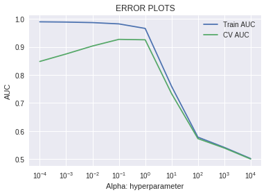

```python
# Please write all the code with proper documentation

alpha= [0.0001,0.001,0.01,0.1,1,10,100,1000,10000]

from sklearn.metrics import roc_auc_score
from sklearn.model_selection import GridSearchCV

nb=MultinomialNB()
parameters= {'alpha':alpha}
clf=GridSearchCV(nb, parameters, cv=3, scoring='roc_auc')
clf.fit(X_Train_BOW, Y_Train)

train_auc=clf.cv_results_['mean_train_score']
train_auc_std=clf.cv_results_['std_train_score']
cv_auc=clf.cv_results_['mean_test_score']
cv_auc_std=clf.cv_results_['std_test_score']

plt.plot(alpha, train_auc, label='Train AUC')

plt.plot(alpha, cv_auc, label='CV AUC')
plt.legend()
plt.xlabel("Alpha: hyperparameter")
plt.ylabel("AUC")
plt.xscale('log')
plt.title("ERROR PLOTS")
plt.show()
```

```python
print(clf.best_params_)
print(clf.best_estimator_)
print(clf.best_score_)
```

```
{'alpha': 0.1}
MultinomialNB(alpha=0.1, class_prior=None, fit_prior=True)
0.9268449054725256
```

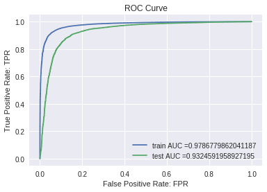

```python
optimal_NB=MultinomialNB(alpha=0.1, class_prior=None, fit_prior=True)
optimal_NB.fit(X_Train_BOW, Y_Train)

train_fpr, train_tpr, thresholds= roc_curve(Y_Train, optimal_NB.predict_proba(X_Train_BOW)[:,1])
test_fpr, test_tpr, thresholds=roc_curve(Y_Test, optimal_NB.predict_proba(X_Test_BOW)[:,1])
train_bow_acc =auc(train_fpr, train_tpr)
test_bow_acc = auc(test_fpr, test_tpr)

plt.plot(train_fpr, train_tpr, label="train AUC ="+str(train_bow_acc))
plt.plot(test_fpr, test_tpr, label="test AUC ="+str(test_bow_acc))
plt.legend()
plt.xlabel("False Positive Rate: FPR")
plt.ylabel("True Positive Rate: TPR")
plt.title("ROC Curve")
plt.show()
```

### [5.1.1] Top 10 important features of positive class from SET 1

```python
# Please write all the code with proper documentation

class_features=optimal_NB.feature_log_prob_
#  row_0 is for 'negative' class and row_1 is for 'positive' class
negative_features=class_features[0]
positive_features=class_features[1]

feature_names=count_vect.get_feature_names()

# Sorting 'positive_features' in descending order using argsort()function. sorted_positive_features holds the index of top +ve features

sorted_positive_features=np.argsort(positive_features)[::-1]

print("\n\nTop 10 Important Features and their log probabilities For Positive Class :\n\n")

for i in list(sorted_positive_features[0:10]):
  print("%s\t -->\t%f  "%(feature_names[i] , positive_features[i]))
```

```
Top 10 Important Features and their log probabilities For Positive Class :


not	 -->	-3.754726
great	 -->	-4.435263
good	 -->	-4.500713
like	 -->	-4.562124
one	 -->	-4.910012
love	 -->	-4.956622
taste	 -->	-4.966760
tea	 -->	-4.972744
coffee	 -->	-4.998359
flavor	 -->	-5.067164
```

### [5.1.2] Top 10 important features of negative class from SET 1

```python
# Please write all the code with proper documentation

# Sorting 'positive_features' in descending order using argsort()function. sorted_negative_features holds the index of top -ve features

sorted_negative_features=np.argsort(negative_features)[::-1]

print("\n\nTop 10 Important Features and their log probabilities For Negative Class :\n\n")

for i in list(sorted_negative_features[0:10]):
  print("%s\t -->\t%f  "%(feature_names[i] , negative_features[i]))
```

```
Top 10 Important Features and their log probabilities For Negative Class :


not	 -->	-3.215333
like	 -->	-4.370493
taste	 -->	-4.629433
would	 -->	-4.679110
product	 -->	-4.713654
one	 -->	-4.897358
good	 -->	-5.006622
coffee	 -->	-5.071734
flavor	 -->	-5.142142
no	 -->	-5.144805
```

```
Train confusion matrix
```

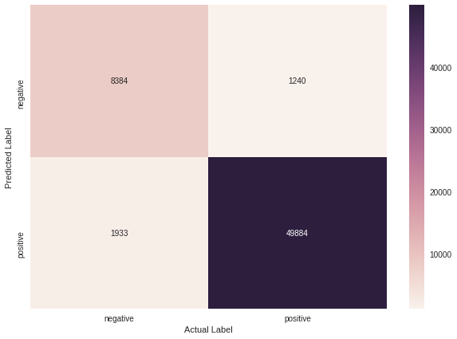

```python
class_names= ['negative','positive']
print("Train confusion matrix")
array = confusion_matrix(Y_Train, optimal_NB.predict(X_Train_BOW))

df_cm = pd.DataFrame(array, index = [i for i in class_names],columns = [i for i in class_names])
plt.figure(figsize = (10,7))
sns.heatmap(df_cm, annot=True,fmt="d")
plt.xlabel("Actual Label")
plt.ylabel("Predicted Label")
plt.show()
```

```
Test confusion matrix
```

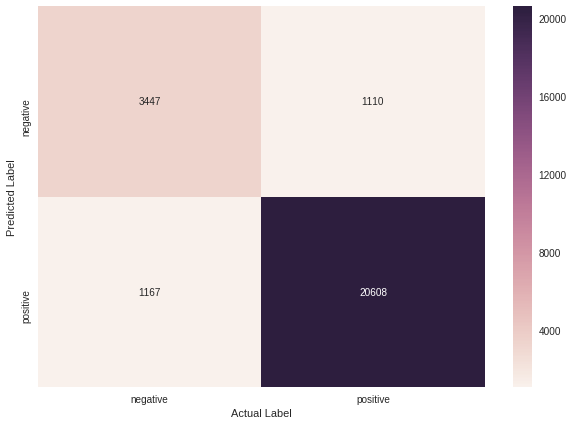

```python
class_names= ['negative','positive']
print("Test confusion matrix")
array = confusion_matrix(Y_Test, optimal_NB.predict(X_Test_BOW))

df_cm = pd.DataFrame(array, index = [i for i in class_names],columns = [i for i in class_names])
plt.figure(figsize = (10,7))
sns.heatmap(df_cm, annot=True,fmt="d")
plt.xlabel("Actual Label")
plt.ylabel("Predicted Label")
plt.show()
```

## [5.2] Applying Naive Bayes on TFIDF, SET 2

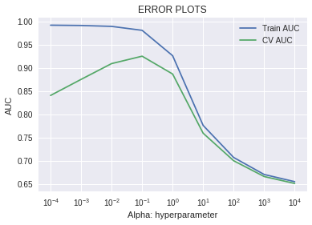

```python
# Please write all the code with proper documentation

alpha= [0.0001,0.001,0.01,0.1,1,10,100,1000,10000]

from sklearn.metrics import roc_auc_score
from sklearn.model_selection import GridSearchCV

nb=MultinomialNB()
parameters= {'alpha':alpha}
clf=GridSearchCV(nb, parameters, cv=3, scoring='roc_auc')
clf.fit(X_Train_TFIDF, Y_Train)

train_auc=clf.cv_results_['mean_train_score']
train_auc_std=clf.cv_results_['std_train_score']
cv_auc=clf.cv_results_['mean_test_score']
cv_auc_std=clf.cv_results_['std_test_score']

plt.plot(alpha, train_auc, label='Train AUC')

plt.plot(alpha, cv_auc, label='CV AUC')
plt.legend()
plt.xlabel("Alpha: hyperparameter")
plt.ylabel("AUC")
plt.xscale('log')
plt.title("ERROR PLOTS")
plt.show()
```

```python
print(clf.best_params_)
print(clf.best_estimator_)
print(clf.best_score_)
```

```
{'alpha': 0.1}
MultinomialNB(alpha=0.1, class_prior=None, fit_prior=True)
0.9251392170134956
```

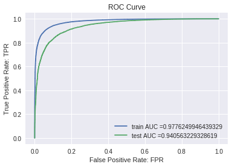

```python
optimal_NB=MultinomialNB(alpha=0.1, class_prior=None, fit_prior=True)
optimal_NB.fit(X_Train_TFIDF, Y_Train)

train_fpr, train_tpr, thresholds= roc_curve(Y_Train, optimal_NB.predict_proba(X_Train_TFIDF)[:,1])
test_fpr, test_tpr, thresholds=roc_curve(Y_Test, optimal_NB.predict_proba(X_Test_TFIDF)[:,1])
train_TFIDF_acc =auc(train_fpr, train_tpr)
test_TFIDF_acc = auc(test_fpr, test_tpr)

plt.plot(train_fpr, train_tpr, label="train AUC ="+str(train_TFIDF_acc))
plt.plot(test_fpr, test_tpr, label="test AUC ="+str(test_TFIDF_acc))
plt.legend()
plt.xlabel("False Positive Rate: FPR")
plt.ylabel("True Positive Rate: TPR")
plt.title("ROC Curve")
plt.show()
```

### [5.2.1] Top 10 important features of positive class from SET 2

```python
# Please write all the code with proper documentation

class_features=optimal_NB.feature_log_prob_
#  row_0 is for 'negative' class and row_1 is for 'positive' class
negative_features=class_features[0]
positive_features=class_features[1]

feature_names=tf_idf_vect.get_feature_names()

# Sorting 'positive_features' in descending order using argsort()function. sorted_positive_features holds the index of top +ve features

sorted_positive_features=np.argsort(positive_features)[::-1]

print("\n\nTop 10 Important Features and their log probabilities For Positive Class :\n\n")

for i in list(sorted_positive_features[0:10]):
  print("%s\t -->\t%f  "%(feature_names[i] , positive_features[i]))
```

```
Top 10 Important Features and their log probabilities For Positive Class :


not	 -->	-4.910125
great	 -->	-4.978739
good	 -->	-5.131800
tea	 -->	-5.269179
coffee	 -->	-5.273769
love	 -->	-5.340229
like	 -->	-5.359322
best	 -->	-5.530332
product	 -->	-5.544479
taste	 -->	-5.564590
```

### [5.2.2] Top 10 important features of negative class from SET 2

```python
# Please write all the code with proper documentation

# Sorting 'positive_features' in descending order using argsort()function. sorted_negative_features holds the index of top -ve features

sorted_negative_features=np.argsort(negative_features)[::-1]

print("\n\nTop 10 Important Features and their log probabilities For Negative Class :\n\n")

for i in list(sorted_negative_features[0:10]):
  print("%s\t -->\t%f  "%(feature_names[i] , negative_features[i]))
```

```
Top 10 Important Features and their log probabilities For Negative Class :


not	 -->	-4.333759
like	 -->	-5.178132
taste	 -->	-5.262192
would	 -->	-5.381201
product	 -->	-5.384952
coffee	 -->	-5.477971
one	 -->	-5.675929
flavor	 -->	-5.733125
no	 -->	-5.774436
good	 -->	-5.791238
```

```
Train confusion matrix
```

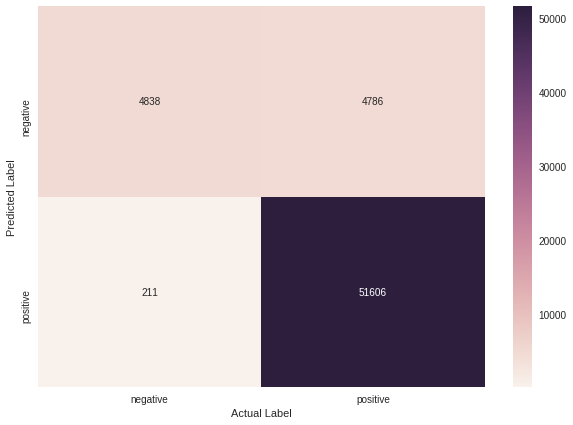

```python
class_names= ['negative','positive']
print("Train confusion matrix")
array = confusion_matrix(Y_Train, optimal_NB.predict(X_Train_TFIDF))

df_cm = pd.DataFrame(array, index = [i for i in class_names],columns = [i for i in class_names])
plt.figure(figsize = (10,7))
sns.heatmap(df_cm, annot=True,fmt="d")
plt.xlabel("Actual Label")
plt.ylabel("Predicted Label")
plt.show()
```

```
Test confusion matrix
```

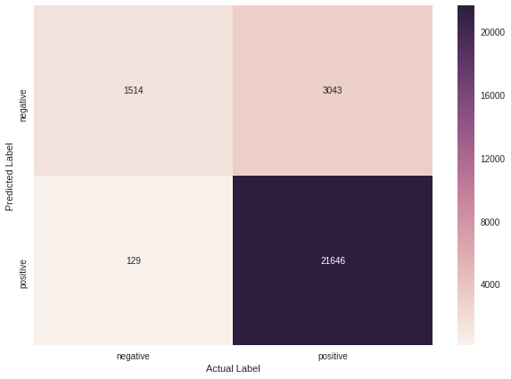

```python
class_names= ['negative','positive']
print("Test confusion matrix")
array = confusion_matrix(Y_Test, optimal_NB.predict(X_Test_TFIDF))

df_cm = pd.DataFrame(array, index = [i for i in class_names],columns = [i for i in class_names])
plt.figure(figsize = (10,7))
sns.heatmap(df_cm, annot=True,fmt="d")
plt.xlabel("Actual Label")
plt.ylabel("Predicted Label")
plt.show()
```

# [6] Conclusions

```python
# Please compare all your models using Prettytable library
from prettytable import PrettyTable

names= [
        "Naive Bayes using BoW",
		    "Naive Bayes using TFIDF",

		]


optimal_Alpha= [0.1,0.1]

train_acc= [
			train_bow_acc,
			train_TFIDF_acc,
			]

test_acc = [
			test_bow_acc,
			test_TFIDF_acc,
 ]
numbering= [1,2]


# Initializing prettytable

ptable=PrettyTable()

 # Adding columns
ptable.add_column("S.NO.",numbering)
ptable.add_column("MODEL",names)
ptable.add_column("Best Alpha",optimal_Alpha)
ptable.add_column("Training Accuracy",train_acc)
ptable.add_column("Test Accuracy",test_acc)

# Printing the Table
print(ptable)
```

```
+-------+-------------------------+------------+--------------------+--------------------+
| S.NO. |          MODEL          | Best Alpha | Training Accuracy  |   Test Accuracy    |
+-------+-------------------------+------------+--------------------+--------------------+
|   1   |  Naive Bayes using BoW  |    0.1     | 0.9786779862041187 | 0.9324591958927195 |
|   2   | Naive Bayes using TFIDF |    0.1     | 0.9776249946439329 | 0.940563229328619  |
+-------+-------------------------+------------+--------------------+--------------------+
```

**Conclusion** :

1. I have taken 100000 data from SQL database.
2. After that I have cleaned the summary and text of the reviews.
3. Merge the Summary and text into new text column.
4. Sort the dataset based on time.
5. Split the dataset into Train and Test based on time.
6. Applied BOW, TFIDF on review text.
7. Applied MultinomialNB on BOW andTFIDF.
8. Inplemented grid Search.
9. Implemented confusion matrix and AOC to see the TP and TN. .